# Coursework Report: Does red influence attractiveness

*N* removed NAs: 3

*N* removed typo: 1

*N* removed <18: 31

*N* total clean: 116

| Group | *N* | *M*<sub>age</sub> | *M*<sub>rating</sub> |
| --- | --- | --- | --- |
| Control | 51 | 21.1 | 5.87 |
| Experim | 65 | 21.5 | 6.19 |

**Main analysis results**

*t*(114) = -2.27, *p* = .025

[interactive chart not shown]

[figure not shown]

[interactive chart not shown]

# Coursework Report: Does red influence attractiveness

Analysing Data, Spring 2020

# Methods

## Participants

*Figure* 1. *Descriptive statistics by Condition*

| Condition | *N* | % | *M*<sub>age</sub> | *SD*<sub>age</sub> |
| --- | --- | --- | --- | --- |
| White | 51 | 44 | 21.1 | 2.15 |
| Red | 65 | 56 | 21.5 | 2.59 |

## Design

The conceptual hypothesis for our study is does red influence how attractive an individual is perceived?

A between-groups design was used, the groups being separated by condition, which is our independent, categorical variable. Participants were either in the control condition, where a photo of a moderately attractive man was used on a white background, or the experimental condition where the same man was shown on a red background. This is our predictor. The dependent variable for this study was the attractiveness ratings for each item (item 1, item 2, item 3), which was measured on a 9-point scale of attractiveness ratings, a continuous variable. The items were the same as the Elliot et al., (2010) experiment we are replicating which were as follows; “How attractive do you think this person is?”, “How pleasant is this person to look at?”, “If you were to meet the person in this picture face to face, would you think he is attractive?”. Possible scores for each item ranged from 1-9, where 1 is not at all attractive and 9 is extremely attractive. This is the outcome as it is the thing that changes depending on the manipulation. These attractiveness ratings are our outcome. The ratings given for the 3 items will be averaged to obtain a composite score which will allow us to compare the mean rating for each condition.

Our operational hypothesis is does viewing a red background on an image of a moderately attractive man, influence the rating of attractiveness given by a female participant? This hypothesis will be tested using the statistical analysis of a *t*-test of the composite score in each condition.

# Results

First, a composite score was created, this is calculated by taking the average of the 3 rating scales; item 1, item 2 and item 3. A graph was then created in order to compare the mean attractiveness ratings (composite score) in both conditions, this was conducted to see if the colour condition did affect how attractive the female participants found the man in the images.

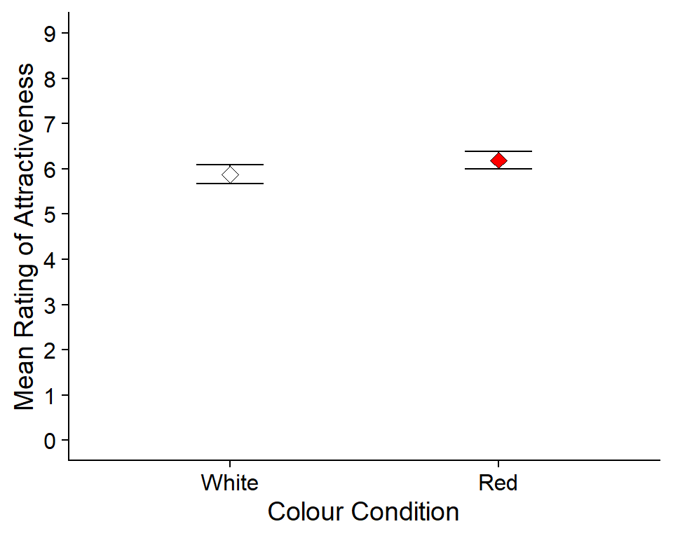

From *Figure* 2, we can see that there is a slight difference in the mean scores, in particular the mean composite score for the attractiveness ratings is higher in the red condition in comparison to the white condition. Both confidence intervals are small and narrow, meaning that the ratings were consistent.

We next investigated, using an independent-measures *t*-test, whether the participants would rate the attractiveness of the man in the image differently depending on the colour condition. The white condition, mean rating of attractiveness was lower (*M* = 5.87) than the mean rating of attractiveness in the red condition (*M* = 6.19). The *t*-test showed that the composite mean scores in the two conditions were slightly different *M*<sub>diff</sub> = -0.32, 95% CI [-0.6, -0.04]) and there was a statistical significant difference between the groups on the ratings of attractiveness (*t* (114) = -2.27, *p* = .025), meaning that we reject the null hypothesis.

# Discussion

The results have concluded that there is a significant difference between the colour condition and the attractiveness rating the participants gave. This supports our hypothesis, that there is a relationship between the colour red and how attractive a female participant finds a moderately attractive man. Although only a slight difference in means between the groups, p < .05, suggesting that there is a significant relationship. These findings are consistent with the findings from the study that we are replicating, Elliot et al. (2010) experiment 1, where they also found that there was a significant effect on the colour condition and the perceived attractiveness.

Despite, the results being consistent with the Elliot et al. (2010) experiment, there has been criticism by Francis (2013), who after close analysis concluded that there is publication bias in his studies, this was specifically due to the experiments underpowering. However, the red-attractiveness effect has been replicated by this study as well as other psychologists, concluding similar results. Elliot and Maier (2013) replication of their own study to respond to this criticism, concluded that there was a difference between conditions but the statistical test found no significance between the red-attractiveness effect.

A study which has found there is a significant relationship between the perceived attractiveness and the colour red, like our study, is an experiment by Young (2015). The study results, showed that the colour red does affect how much a woman is attracted to a man. However, in contrast to our study, they compared the results with the participants initial ratings of the man. The results showed that only those who pre-rated the man as attractive, continued to rate them as attractive in conjunction with the colour red, showing that red did not influence previously perceived unattractive faces.

There were studies which do not support our findings, that there is a relationship between the colour red and the perceived attractiveness of a man. Peperkoom, Roberts and Pollet (2016) conducted 3 studies to see if there is a red effect on mate preferences. The results failed to support the prediction that red clothing enhances attractiveness ratings. Although, they did used the male participants and a woman in the colour red clothing, which is different to our experiment, so this may have had an effect on the results. Also, Hesslinger, Goldback and Carbon (2015) replicated the Elliot et al. experiment, to see if red clothing effected the attractiveness of a man, interestingly they found that there was no significant impact of the colour red but instead, the clothing style was significant. This could point towards an area of further research, into an experiment on the type of clothing, its style and the colour effect on the attractiveness of the man. Another suggestion for further research would be to use a larger sample size when finding the significance of the colour red on attractiveness, to increase the reliability, as with these types of studies they are usually not as large.

It is important to look at the strengths and limitations of our study. A strength of this study is it is a direct replication, so we can expect to see similar results. However, a limitation of this is, similar limitations of Elliot et al. (2010) Experiment 1 study design could occur. A between-groups design, is more straightforward as there can be no carry-over effect between conditions, a strength of this type of design. However, our sample size was reduced due to the NAs, errors in data recording and participants being under the age of 18. This highlights a limitation of our study as a smaller sample size in a between-groups design, could mean that the results could be less reliable.

Another limitation, is the age group of our participants, by *M*<sub>age</sub> = 21.3 (*min*<sub>age</sub> = 18, *max*<sub>age</sub> 28), it might be that the results from this experiment is not representative of the older population, meaning the sample may not be representative of the wider population. As well as this, the experiment lacked ecological validity, particularly, the stimulus material used, a photograph of a moderately attractive man, may not reflect the varying physiques which we see in real-life society. Also, the clothing the man was wearing may have had an impact on the perceived attractiveness of the man. These ecological issues may have an impact on our results as woman may have different characteristics that they see as attractive in a man.

To conclude, our findings did support our hypothesis, that red does affect the perceived attractiveness of a man. However, further research with larger sample sizes is needed, in order to see if it is only the factor red, or if the clothing style, physique or the initial perceived attractiveness, that affects the perceived attractiveness.

# References

Elliot, A., Niesta Kayser, D., Greitemeyer, T., Lichtenfeld, S., Gramzow, R., Maier, M. and Liu, H. (2010). Red, rank, and romance in women viewing men. Journal of Experimental Psychology: General, 139(3), pp.399-417.

Elliot, A., & Maier, M. (2013). The red-attractiveness effect, applying the Ioannidis and Trikalinos (2007b) test, and the broader scientific context: A reply to Francis (2013). Journal Of Experimental Psychology: General, 142(1), 297-300. doi: 10.1037/a0029592

Francis, G. (2013). Publication bias in “Red, rank, and romance in women viewing men,” by Elliot et al. (2010). Journal Of Experimental Psychology: General, 142(1), 292-296. doi: 10.1037/a0027923

Hesslinger, V., Goldbach, L., & Carbon, C. (2015). Men in red: A reexamination of the red-attractiveness effect. Psychonomic Bulletin & Review, 22(4), 1142-1148. doi: 10.3758/s13423-015-0866-8

Peperkoorn, L., Roberts, S., & Pollet, T. (2016). Revisiting the Red Effect on Attractiveness and Sexual Receptivity. Evolutionary Psychology, 14(4), pp.1-11

Young, S. (2015). The effect of red on male perceptions of female attractiveness: Moderation by baseline attractiveness of female faces. European Journal Of Social Psychology, 45(2), 146-151. doi: 10.1002/ejsp.2098